# L1

Kushtanov Dmitry

## Исходные данные

Экспоненциальное распределение определяется следующей функцией распределения:

```
F(x) = 1 - e^(-λ⋅x)
```

## Задание 1

1. Сгенерируйте 200 случайных значений из стандартного экспоненциального распределения и сохраните в вектор *exp.1*. Найдите среднее и стандартное отклонение из данных этого вектора.

```r
 exp.1<-rexp(n=200)
 mean(exp.1)
```

```
## [1] 1.135149
```

```r
 sd(exp.1)
```

```
## [1] 1.134964
```

2. Повторите, использовав следующие значения параметра λ: 0.1, 0.5, 5, 10, и сохраните результаты в векторы: *exp.0.1*, *exp.0.5*, *exp.5*, *exp.10*.

```r
exp.0.1<-rexp(n=200, rate = 0.1)
mean(exp.0.1)
```

```
## [1] 10.3491
```

```r
sd(exp.0.1)
```

```
## [1] 9.7912
```

```r
exp.0.5<-rexp(n=200, rate = 0.5)
mean(exp.0.5)
```

```
## [1] 2.231899
```

```r
sd(exp.0.5)
```

```
## [1] 2.143768
```

```r
exp.5<-rexp(n=200,rate = 5)
mean(exp.5)
```

```
## [1] 0.1980969
```

```r
sd(exp.5)
```

```
## [1] 0.1964387
```

```r
exp.10<-rexp(n=200,rate = 10)
mean(exp.10)
```

```
## [1] 0.09809472
```

```r
sd(exp.10)
```

```
## [1] 0.09583379
```

3. Функция `plot()` общая функция для визуализации данных. Функция `hist()` принимает данные и раскладывает их по корзинам. Чтобы использовать эти функции нужно для начала передать им данные, которые хотим визуализировать.
4. Используйте функцию `hist()` для построения гистограммы полученного ранее стандартного распределения.

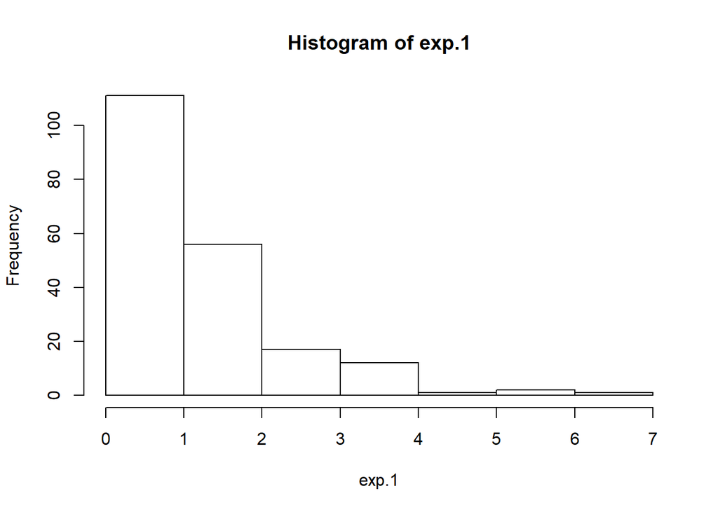

```r
  hist(exp.1)
```

2. Используйте функцию `plot()` с тем же самым вектором для построения графика значений в порядке следования.

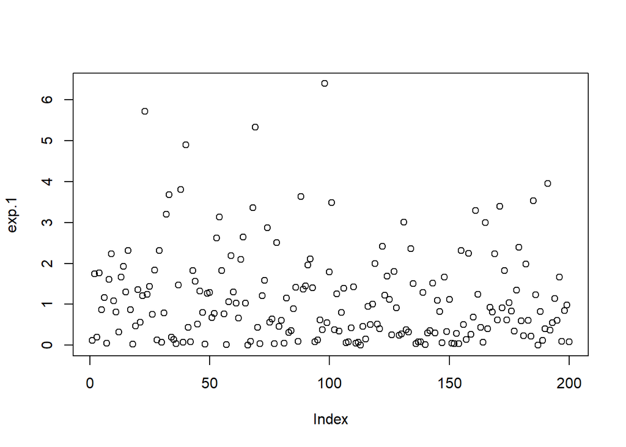

```r
plot(exp.1)
```

Значения случайных величин 3. Используйте функцию `plot()` с любыми двумя полученными ранее векторами, чтобы получить диаграмму рассеяния ([scatterplot](https://www.mathsisfun.com/data/scatter-xy-plots.html)) этих векторов относительно друг друга.

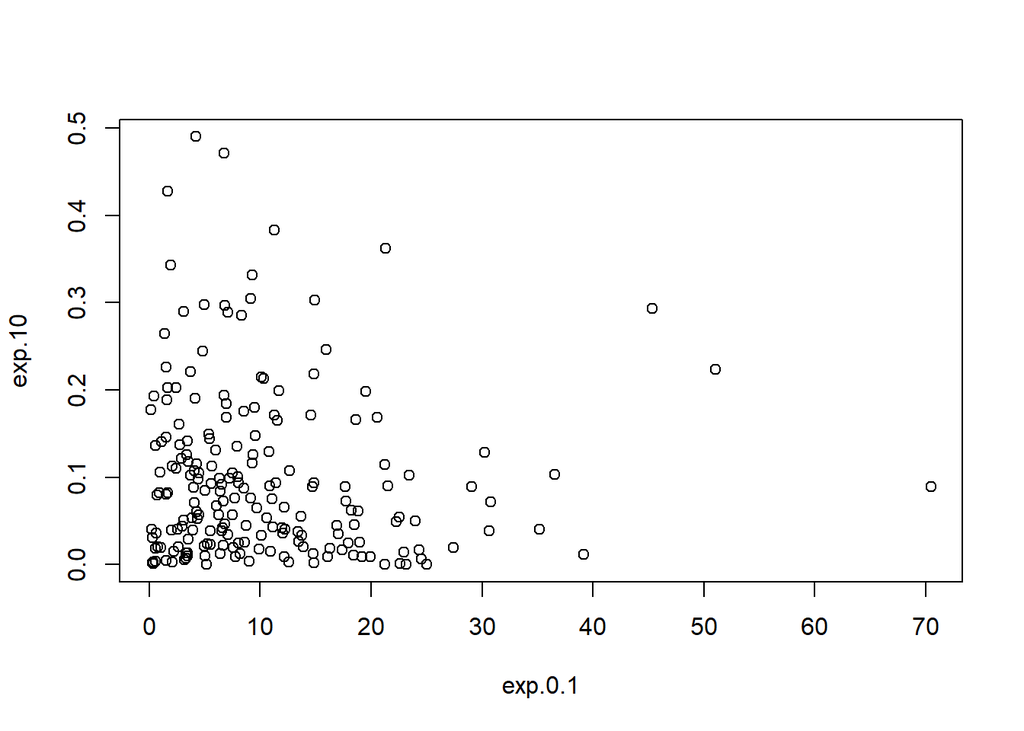

```r
plot(exp.0.1, exp.10)
```

Частота и сила отклонений от средних значений 4. Теперь сравним свойства всех наших векторов. Для начала создадим вектор, содержащий средние значения каждого из 5 полученных ранее распределений в порядке их создания. Полученный вектор сохраним в переменную *exp.means*. Далее необходимо создать следующие диаграммы рассеяния:

```r
exp.means<-c(mean(exp.1), mean(exp.0.1), mean(exp.0.5), mean(exp.5), mean(exp.10))
head(exp.means)
```

```
## [1]  1.13514920 10.34909768  2.23189860  0.19809689  0.09809472
```

1. Вектор с пятью средними относительно каждого из пяти векторов с различными значениями λ.

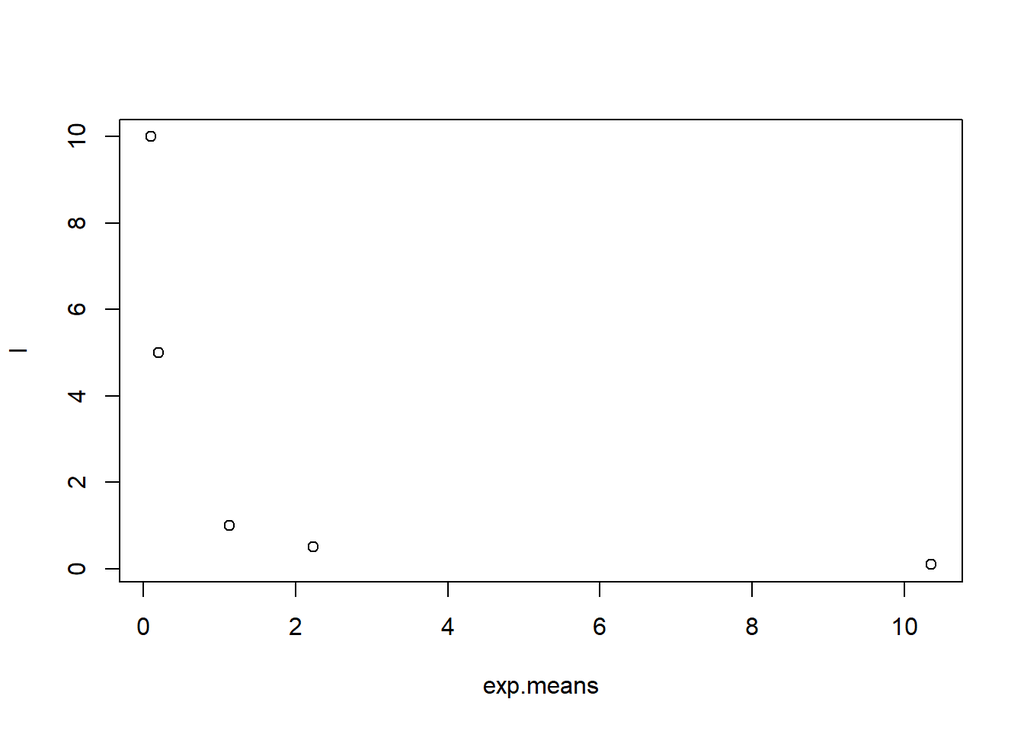

```r
l<-c(1,0.1,0.5,5,10)
plot(exp.means, l)
```

Отображение средних значений для каждого значения распределения 2. Вектор с пятью стандартными отклонениями относительно каждого из пяти векторов с различными значениями λ.

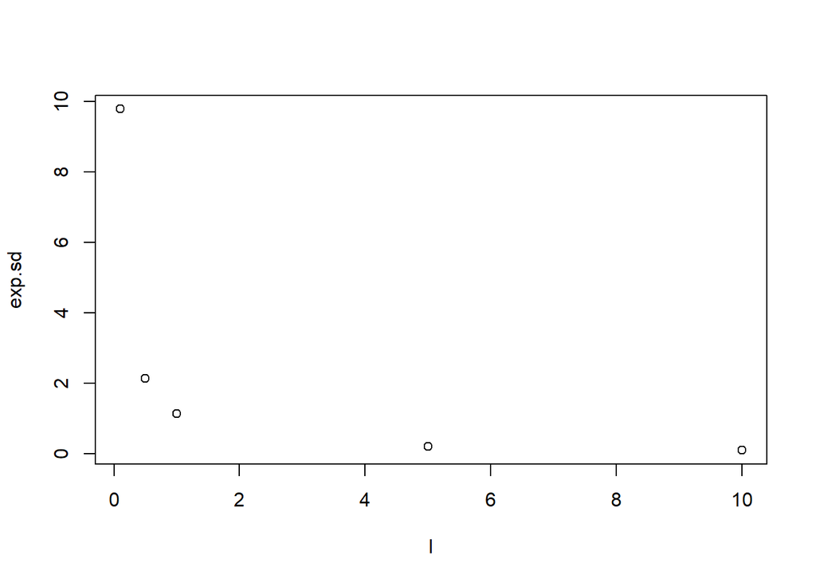

```r
exp.sd<-c(sd(exp.1), sd(exp.0.1), sd(exp.0.5), sd(exp.5), sd(exp.10))
plot(l, exp.sd)
```

Отображение стандартных отклонений для каждого значения распределения 3. Вектор с пятью средними относительно вектора с пятью стандартными отклонениями.

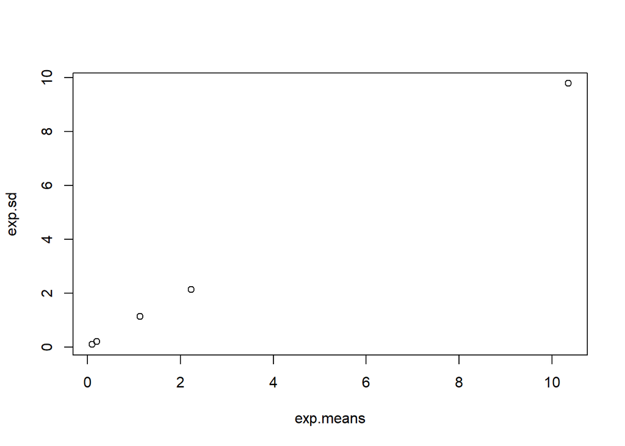

```r
plot(exp.means, exp.sd)
```

Зависимость средних значений от стандартных отклонений ## Задание 2 R достаточно производителен, чтобы вычислять относительно большие объёмы данных. * Для демонстрации сгенерируйте 1100000 (1 млн. 100 тысяч) чисел из стандартного экспоненциального распределения и сохраните их в вектор *huge.exp.1*. Получите среднее и стандартное отклонение.

```r
huge.exp.1<-rexp(1100000)
head(mean(huge.exp.1))
```

```
## [1] 1.000236
```

```r
head(sd(huge.exp.1))
```

```
## [1] 1.000528
```

- Получите гистограмму *huge.exp.1*. Она соответствует функции `1 - e:^(-x)`? Должна ли?

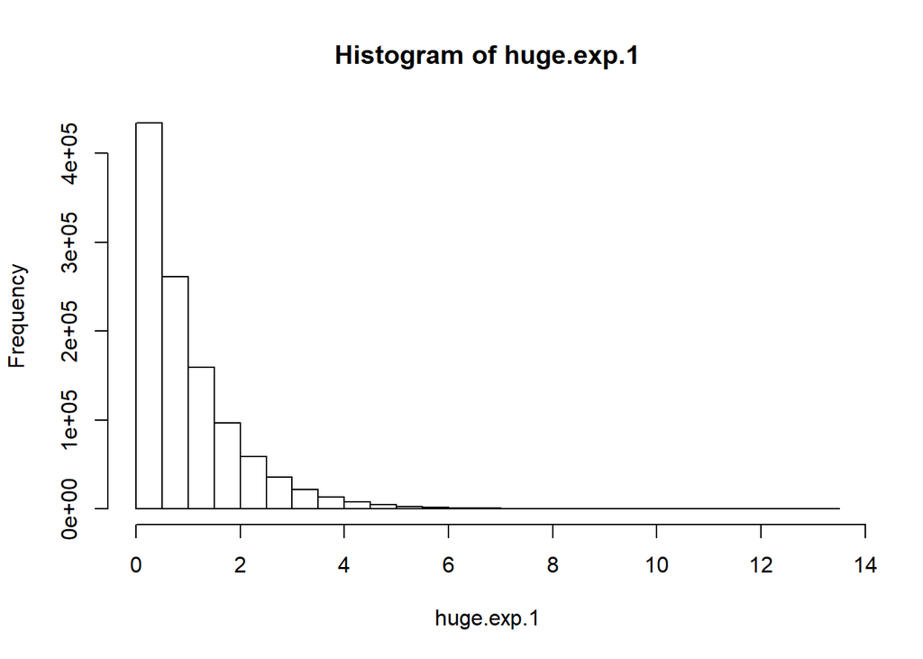

```r
hist(huge.exp.1)
```

Нет. Нет

- Получите среднее всех чисел из *huge.exp.1* строго больших 1. Для проверки выборки может потребоваться новый вектор.

```r
mean(huge.exp.1[huge.exp.1>1])
```

```
## [1] 2.001249
```

- Получите матрицу *huge.exp.1.mat*, содержащую 1100 строк и 1000 колонок. Постройте гистограмму, использовав полученную матрицу. Что можно сказать о полученных данных?

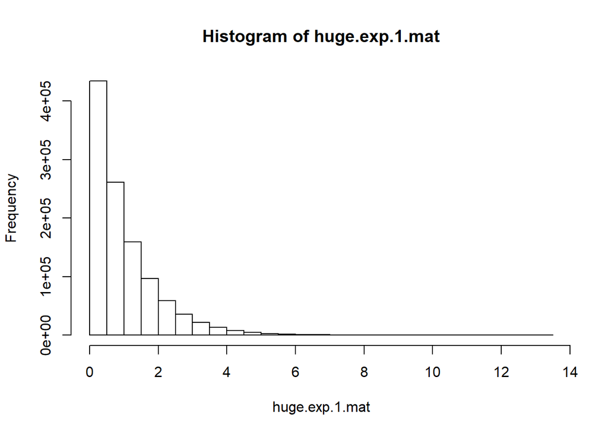

```r
huge.exp.1.mat<-array(huge.exp.1, dim = c(1100,1000))
hist(huge.exp.1.mat)
```

Частота встречаемости значений * Рассчитайте среднее 137-й колонки из *huge.exp.1.mat*.

```r
head(mean(huge.exp.1.mat[,137]))
```

```
## [1] 0.9489639
```

- Найдите среднее всей 1000 колонок и сохраните их в вектор. Отобразите диаграмму средних зннчений колонок. Объясните почему форма диаграммы отличается от виденных ранее.

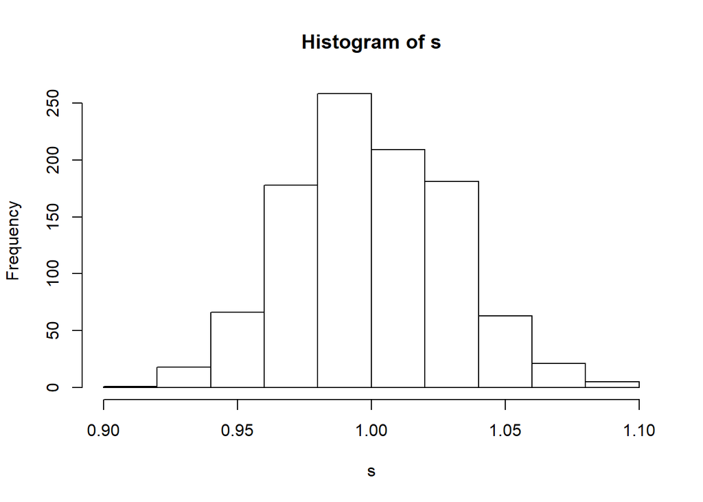

```r
s<-vector(mode = 'integer', length = 1000)
for (i in 1:1000)
{
  s[i]<-mean(huge.exp.1.mat[,i])
}

hist(s)
```

Отображает частоту отклонений средних значений * Рассчитайте квадрат каждого значения из *huge.exp.1* и найдите среднее и стандартное отклонение полученного вектора квадратов. Объясните отличие от соответствующих показателей вектора *huge.exp.1*. Вам может помочь формула, по которой R рассчитывает стандартное отклонение: `sqrt(sum((x - mean(x))^2) / (n - 1))`.

```r
head(mean(huge.exp.1*huge.exp.1))
```

```
## [1] 2.001526
```

```r
head(sd(huge.exp.1*huge.exp.1))
```

```
## [1] 4.474907
```

Значения отличаются